# Assignment #4

Minghao Du

# Set-up

Load packages.

```r
rm(list = ls())
library(readxl)
library(tidyverse)
library(ggplot2)
```

For this and the next assignments (Assignment 3 and 4), you will use the dataset from https://www.ibm.com/communities/analytics/watson-analytics-blog/it-help-desk/. (the link is now invalid.) This data is from an Information Technology (IT) department interested in improving the satisfaction of customers.  
To start their analysis, they constructed this data set of 100,000 closed tickets that were filed at their help desk.

Load the dataset and save it as ithelp.

```r
ithelp <- read_excel("WA_Fn-UseC_-IT-Help-Desk.xlsx")
```

```r
glimpse(ithelp)
```

```
Rows: 100,000
Columns: 10
$ ticket             <dbl> 1, 2, 3, 4, 5, 6, 7, 8, 9, 10, 11, 12, 13, 14, 15, 16, 17, 18~
$ Requestor          <dbl> 1929, 1587, 925, 413, 318, 858, 1978, 1209, 887, 1780, 1349, ~
$ RequestorSeniority <chr> "1 - Junior", "2 - Regular", "2 - Regular", "4 - Management",~
$ ITOwner            <dbl> 50, 15, 15, 22, 22, 38, 10, 1, 14, 46, 1, 50, 11, 26, 9, 7, 2~
$ FiledAgainst       <chr> "Systems", "Software", "Access/Login", "Systems", "Access/Log~
$ TicketType         <chr> "Issue", "Request", "Request", "Request", "Request", "Request~
$ Severity           <chr> "2 - Normal", "1 - Minor", "2 - Normal", "2 - Normal", "2 - N~
$ Priority           <chr> "0 - Unassigned", "1 - Low", "0 - Unassigned", "0 - Unassigne~
$ daysOpen           <dbl> 3, 5, 0, 20, 1, 0, 9, 15, 6, 1, 7, 17, 10, 4, 7, 11, 0, 7, 7,~
$ Satisfaction       <chr> "1 - Unsatisfied", "1 - Unsatisfied", "0 - Unknown", "0 - Unk~
```

A total of 100,000 rows. Each row represent an individual request. The data includes:

- Requestor: employee who submitted the ticket
- RequestorSeniority: employee’s seniority within the company
- ITOwner: IT employee who serviced the ticket
- FileAgainst: functional area against which the ticket was filed (systems, software, hardware, access)
- TicketType: whether the ticket was a request for new services or an issue with existing services
- Severity: submitter-assigned severity of the ticket
- Priority: IT-assigned priority of the ticket
- daysOpen: number of days the ticket was open
- Satisfaction: satisfaction with the resolution of the ticket (reported by the submitter)

```r
summary(ithelp)
```

```
     ticket         Requestor    RequestorSeniority    ITOwner      FiledAgainst
 Min.   :     1   Min.   :   1   Length:100000      Min.   : 1.00   Length:100000
 1st Qu.: 25001   1st Qu.: 499   Class :character   1st Qu.:13.00   Class :character
 Median : 50001   Median : 999   Mode  :character   Median :26.00   Mode  :character
 Mean   : 50001   Mean   : 999                      Mean   :25.46
 3rd Qu.: 75000   3rd Qu.:1499                      3rd Qu.:38.00
 Max.   :100000   Max.   :2000                      Max.   :50.00
  TicketType          Severity           Priority            daysOpen
 Length:100000      Length:100000      Length:100000      Min.   : 0.000
 Class :character   Class :character   Class :character   1st Qu.: 1.000
 Mode  :character   Mode  :character   Mode  :character   Median : 5.000
                                                          Mean   : 6.843
                                                          3rd Qu.:10.000
                                                          Max.   :54.000
 Satisfaction
 Length:100000
 Class :character
 Mode  :character
```

Some ‘character’ variables behave unexpectedly. Let’s convert all character variables into factors, which indicate categorical variables in R.

```r
ithelp<-ithelp%>%
  mutate(ticket=as.factor(ticket),
         Requestor=as.factor(Requestor),
         RequestorSeniority=as.factor(RequestorSeniority),
         ITOwner=as.factor(ITOwner),
         FiledAgainst=as.factor(FiledAgainst),
         TicketType=as.factor(TicketType),
         Severity=as.factor(Severity),
         Priority=as.factor(Priority),
         Satisfaction=as.factor(Satisfaction))
```

Let’s check the summary again.

```r
summary(ithelp)
```

```
     ticket        Requestor          RequestorSeniority    ITOwner
 1      :    1   285    :   74   1 - Junior    :20040    3      : 2084
 2      :    1   754    :   74   2 - Regular   :41303    39     : 2080
 3      :    1   79     :   73   3 - Senior    :18801    48     : 2072
 4      :    1   636    :   72   4 - Management:19856    35     : 2058
 5      :    1   1341   :   72                           24     : 2045
 6      :    1   523    :   70                           4      : 2040
 (Other):99994   (Other):99565                           (Other):87621
       FiledAgainst     TicketType                Severity               Priority
 Access/Login:29921   Issue  :24926   0 - Unclassified:  367   0 - Unassigned:30127
 Hardware    : 9976   Request:75074   1 - Minor       : 2317   1 - Low       :17117
 Software    :20068                   2 - Normal      :90912   2 - Medium    :16258
 Systems     :40035                   3 - Major       : 4974   3 - High      :36498
                                      4 - Critical    : 1430


    daysOpen                    Satisfaction
 Min.   : 0.000   0 - Unknown         :30211
 1st Qu.: 1.000   1 - Unsatisfied     :21124
 Median : 5.000   2 - Satisfied       :19602
 Mean   : 6.843   3 - Highly satisfied:29063
 3rd Qu.:10.000
 Max.   :54.000
```

It turns out that there are many cases with “Unknown” Satisfaction. Let’s exclude these cases from the analysis (Step 1: filter). Next, we may build a multi-class classification model (Unsatisfied, Satisfied, Highly satisfied), but let’s simplify it to a binary classifier and identify “Unsatisfied” cases, which are problematic. Create a new variable, “negative”, which indicates if a user’s feedback is negative (Step 2: mutate). The following code will do these jobs for you.

```r
ithelp<-ithelp%>%
  filter(Satisfaction!="0 - Unknown")%>%
  mutate(negative=as.factor(ifelse(Satisfaction =="1 - Unsatisfied","Yes","No")))

summary(ithelp)
```

```
     ticket        Requestor          RequestorSeniority    ITOwner
 1      :    1   442    :   56   1 - Junior    :13995    39     : 1470
 2      :    1   1489   :   55   2 - Regular   :28963    24     : 1442
 5      :    1   98     :   53   3 - Senior    :13027    19     : 1440
 9      :    1   248    :   53   4 - Management:13804    3      : 1437
 10     :    1   1391   :   53                           48     : 1437
 12     :    1   1498   :   53                           31     : 1435
 (Other):69783   (Other):69466                           (Other):61128
       FiledAgainst     TicketType                Severity               Priority
 Access/Login:20990   Issue  :17454   0 - Unclassified:  263   0 - Unassigned:20984
 Hardware    : 6912   Request:52335   1 - Minor       : 1620   1 - Low       :12045
 Software    :13972                   2 - Normal      :63459   2 - Medium    :11409
 Systems     :27915                   3 - Major       : 3445   3 - High      :25351
                                      4 - Critical    : 1002


    daysOpen                   Satisfaction   negative
 Min.   : 0.00   0 - Unknown         :    0   No :48665
 1st Qu.: 1.00   1 - Unsatisfied     :21124   Yes:21124
 Median : 5.00   2 - Satisfied       :19602
 Mean   : 6.83   3 - Highly satisfied:29063
 3rd Qu.:10.00
 Max.   :49.00
```

# Set up for holdout validation

Let’s select 20% of dataset. Using these indices, we will create a test and a training dataset.

```r
set.seed(1)   # set a random seed
index <- sample(nrow(ithelp), nrow(ithelp)*0.2) # random selection of indices.
test <- ithelp[index,]       # save 20% as a test dataset
training <-ithelp[-index,]   # save the rest as a training set
```

# Tree model

```r
library(rpart)
library(rpart.plot)
```

Build the same model to predict “negative”, with the following variables. * RequestorSeniority * FiledAgainst * TicketType * Severity * Priority * daysOpen

But this time, we will make two changes. 1. Instead of the entire dataset for training (ithelp), you will use the training dataset (training). 2. Generate a bigger tree with cp=0. Set `control=rpart.control(cp=0)`.

Save the model as `ct_model`. We will skip plotting the tree. It may crash.

```r
ct_model<-rpart(negative~RequestorSeniority+FiledAgainst+TicketType+Severity+Priority+daysOpen,           # model formula
                data=training,                     # dataset
                method="class",                   # "class" indicates a classification tree model
                control=rpart.control(cp=0))   # tree control parameters.
```

Check the cross-validation result using `printcp()`.

```r
printcp(ct_model)
```

```
Classification tree:
rpart(formula = negative ~ RequestorSeniority + FiledAgainst +
    TicketType + Severity + Priority + daysOpen, data = training,
    method = "class", control = rpart.control(cp = 0))

Variables actually used in tree construction:
[1] daysOpen           FiledAgainst       Priority           RequestorSeniority
[5] Severity           TicketType

Root node error: 16889/55832 = 0.3025

n= 55832

           CP nsplit rel error  xerror      xstd
1  4.1842e-03      0   1.00000 1.00000 0.0064265
```

[output cut: 44 more lines]

Prune the tree using the cp value with the minimum xerror. Save the result as `min_xerror_tree`.

```r
# prune tree with minimum cp value
min_xerror_tree <-
  prune(ct_model, cp = ct_model$cptable[which.min(ct_model$cptable[, "xerror"]), ][1])
```

Apply this model to the test dataset to get the predicted probabilities.

```r
test$predicted_Prob <- predict(min_xerror_tree,test)[,2]
```

Using the 50% cut-off, generate class prediction.

```r
test$predicted_Prob_YN <- ifelse(test$predicted_Prob>0.5,"Yes","No")
```

## Question 1. What is the error rate of this model when we use the 50% cut-off?

```r
table(test$negative == test$predicted_Prob_YN)
```

```
FALSE  TRUE
 4173  9784
```

```r
nrow(test[test$negative != test$predicted_Prob_YN,]) / nrow(test)
```

```
[1] 0.2989898
```

## Question 2. Generate a confusion table of this model. What is the false positive rate of this model?

```r
table(test$predicted_Prob_YN,
      test$negative,
      dnn = c("predicted", "actual"))
```

```
         actual
predicted   No  Yes
      No  9522 3973
      Yes  200  262
```

```r
nrow(test %>% filter(test$predicted_Prob_YN == "Yes", test$negative == "No")) / nrow(test %>% filter(test$negative == "No"))
```

```
[1] 0.0205719
```

# Logit Regression Model

Using the training dataset, build a logit regression model to predict “negative”, with the following variables. * RequestorSeniority * FiledAgainst * TicketType * Severity * Priority * daysOpen

Again, be sure to use `training’ dataset for model building.

```r
logit_model <-
  glm(
    negative ~ RequestorSeniority + FiledAgainst + TicketType + Severity + Priority +
      daysOpen,
    # model formula
    data = training,
    family = "binomial"
  )
summary(logit_model)
```

```
Call:
glm(formula = negative ~ RequestorSeniority + FiledAgainst +
    TicketType + Severity + Priority + daysOpen, family = "binomial",
    data = training)

Deviance Residuals:
    Min       1Q   Median       3Q      Max
-1.8316  -0.8300  -0.7416   1.3139   2.1780

Coefficients:
                                  Estimate Std. Error z value Pr(>|z|)
(Intercept)                      -0.181140   0.147158  -1.231 0.218352
RequestorSeniority2 - Regular     0.031778   0.026162   1.215 0.224500
RequestorSeniority3 - Senior     -0.075648   0.032761  -2.309 0.020938 *
RequestorSeniority4 - Management -0.011964   0.032933  -0.363 0.716404
FiledAgainstHardware             -1.516031   0.050537 -29.999  < 2e-16 ***
FiledAgainstSoftware             -0.481388   0.029355 -16.399  < 2e-16 ***
FiledAgainstSystems              -0.774230   0.029369 -26.362  < 2e-16 ***
TicketTypeRequest                -0.405046   0.023264 -17.411  < 2e-16 ***
Severity1 - Minor                 0.168235   0.155224   1.084 0.278444
Severity2 - Normal               -0.389170   0.144768  -2.688 0.007183 **
Severity3 - Major                -0.994141   0.151898  -6.545 5.96e-11 ***
Severity4 - Critical             -0.932085   0.168127  -5.544 2.96e-08 ***
Priority1 - Low                  -0.100680   0.029684  -3.392 0.000694 ***
Priority2 - Medium                0.036698   0.028956   1.267 0.205022
Priority3 - High                  0.078909   0.023990   3.289 0.001004 **
daysOpen                          0.083506   0.001913  43.640  < 2e-16 ***
---
Signif. codes:  0 ‘***’ 0.001 ‘**’ 0.01 ‘*’ 0.05 ‘.’ 0.1 ‘ ’ 1

(Dispersion parameter for binomial family taken to be 1)

    Null deviance: 68446  on 55831  degrees of freedom
Residual deviance: 66201  on 55816  degrees of freedom
AIC: 66233

Number of Fisher Scoring iterations: 4
```

Apply this model to the test dataset to get the predicted probabilities.

```r
test$logit_pred_prob<-predict(logit_model,test,type="response")
test$logit_pred_class<-ifelse(test$logit_pred_prob>0.5,"Yes","No")
```

# Performance Visualization with ROC

Plot ROC curves of the tree model and logit regression mode you developed.

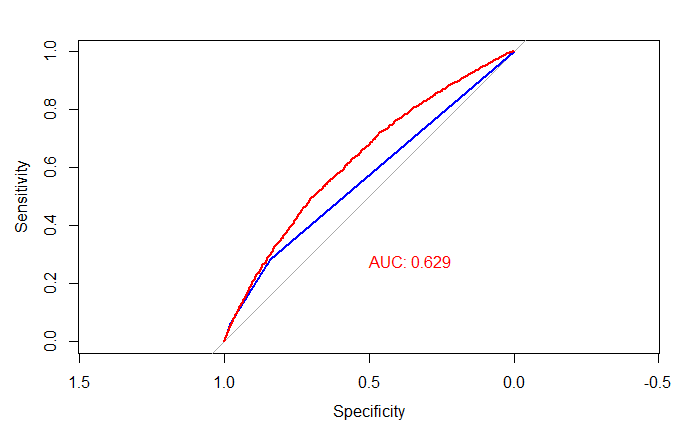

```r
library(pROC)
tree_roc <- roc(test$negative, test$predicted_Prob, auc=TRUE)
logit_roc<-roc(test$negative,test$logit_pred_prob,auc=TRUE)
plot(tree_roc, pront.auc = TRUE,col="blue")
plot(logit_roc,print.auc=TRUE,print.auc.y=.3,add=TRUE,col="red")
```

## Question 3. What are AUCs of the classification tree model?

```r
tree_roc$auc
```

```
Area under the curve: 0.564
```

## Question 4. What are AUCs of the logit regression model?

```r
logit_roc$auc
```

```
Area under the curve: 0.6292
```

## Question 5

The same as the previous assignments, your last task is creating a report. Change the author name on the top of this R markdown file to yours. Compile this R markdown file into a Word document and submit it through the course Blackboard.